# A3: SPL Library Checkouts

### Introduction

An introduction of the data and a description of the trends/books/items you are choosing to analyze (and why!)

The dataset contains all checkout records made by patrons of the Seattle Public Library, including information such as the checkout date, book title, and book type. By analyzing checkout trends over time, I hope to gain insight into people’s interests in different types of books. This analysis can inform the library’s planning to better align with people’s interests, both now and in the future.

### Summary Information

Write a summary paragraph of findings that includes the 5 values calculated from your summary information R script

In the sumamry.R, I first calculate the rank of CheckoutType in the dataset based on the number of different checkout type that was recorded, and I found that Freegal has 823 record, hoopla has 2158, Horizon has 462058, OverDrive has 348678, Zinio has 2637. So, the most frequent checkout type is Horizon.

Besides, I explore the question: How has the number of print book checkouts changed over time? The plot shows that start from year 2019, the number of Print book checkouts drop dramatically, then it increase a little bit. However, starts from 2022, the number keep dropping.

Also, I did a similar thing, I explore What is the month or year with the most/least checkouts for ebooks? The data analysis shows that Most checkouts in a year: 2020 , Least checkouts in a year: 2023 ,Most checkouts in a month: 1 ,Least checkouts in a month: 2;

After that, in the fifth question, I explore What is the most popular publisher, I found that the most popular publisher is: Random House, Inc.

```
## $most_frequent_checkout
## [1] "Horizon"
##
## $year_max
## [1] "2017"
##
## $year_min
## [1] "2017"
##
## $month_max
## [1] "1"
##
## $month_min
## [1] "1"
##
## $year_max_1
## [1] "2020"
##
## $year_min_1
## [1] "2023"
##
## $month_max_1
## [1] "1"
##
## $month_min_1
## [1] "2"
##
## $Q4
## $Q4[[1]]
##
##  2017  2018  2019  2020  2021  2022  2023
## 73048 69146 69058 17363 31293 41747  4100
##
##
## $popular_publisher
## [1] "Random House, Inc."
```

### The Dataset

- Who collected/published the data?

  The data for this assignment comes from the Seattle Public Library.
- What are the parameters of the data (dates, number of checkouts, kinds of books, etc.)?

  The parameters of the data are UsageClass CheckoutType MaterialType CheckoutYear CheckoutMonth Checkouts Title ISBN Creator Subjects Publisher PublicationYear.
- How was the data collected or generated?

  This dataset was collected by Seattle Public Library, it was collected when people check out their book. The dataset start from 2005 and end 2023. However, since the original dataset is too big that is hard to fit in our computer so the dataset was generated to a smaller size that can fit in our computer.
- Why was the data collected?

  There is not an offical explanation. Based on the several analyzing on the data set, I think the reason should be helping people to record the action of the book in order to figure out if the book was borrowed out or not. Then, library can build a system based on that to let costumer figure out the way to access their book in system.
- What, if any, ethical questions do you need to consider when working with this data?

  I believe that there is not an ethical questions that I need to consider when working on the data since these data was published to public, and it only record the book’s action in the library. So, there is not any personal information and not any thing we can do to harm the society based on analyzing the data set.
- What are possible limitations or problems with this data? (at least 200 words)

  Although the dataset record a lot of things about book, it still has limitation. For example, when I analyze the data, I found that the data let me feel confuse. In the column called ‘MaterialType’, there are severael value called EBOOK, AUDIOBOOK,and similar item. Usually, we think the these sub division should belong to EBOOK. So, when I analyze the data, I am not sure if I need to consider the AUDIOBOOK as EBOOK since the AUDIOBOOK was recorded on computer.

### First Trends Over Time Chart

Include a chart. Make sure to describe why you included the chart, and what patterns emerged

I include the chart because I want to know people’s interested over year. Then, we can use the chart to figure out if there is a relationship between the book that people interested in and other factor if other database was provided. For example, if there is a data set that record the things that happend over all in everyday, then we can figure out what type of things that happen the most and their topic. Then, we can try to see if there is a relationship between the topic of events happend and the type of book that people read.

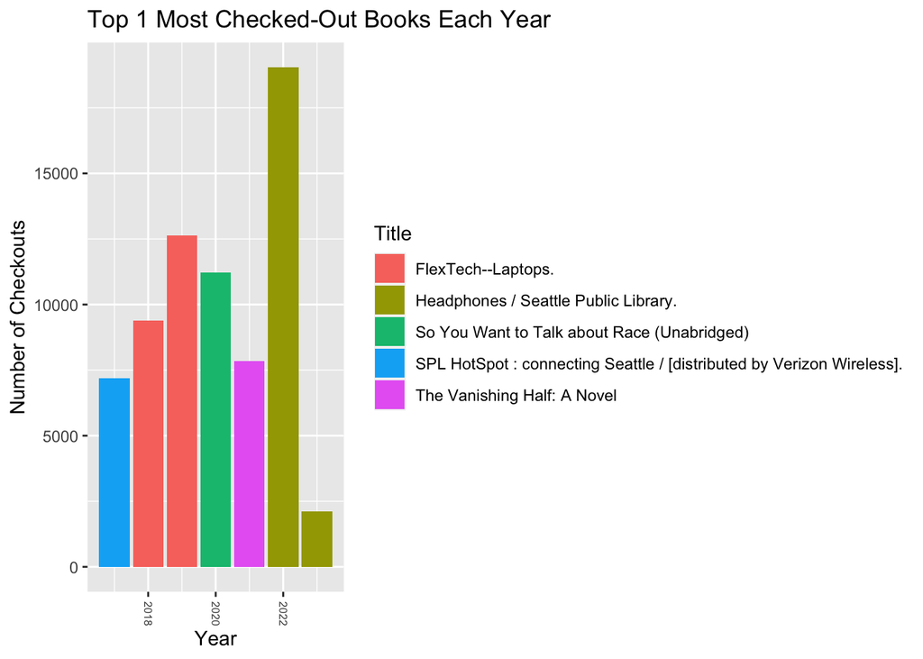

### Second Trends Over Time Chart

-Include a chart. Make sure to describe why you included the chart, and what patterns emerged

I include this plot since I want to figure out how the number of checkout change for different type of books over year. So, we can try to predict what the data will be in the next year and to see what kind of book’s checkout number drop dramatically.

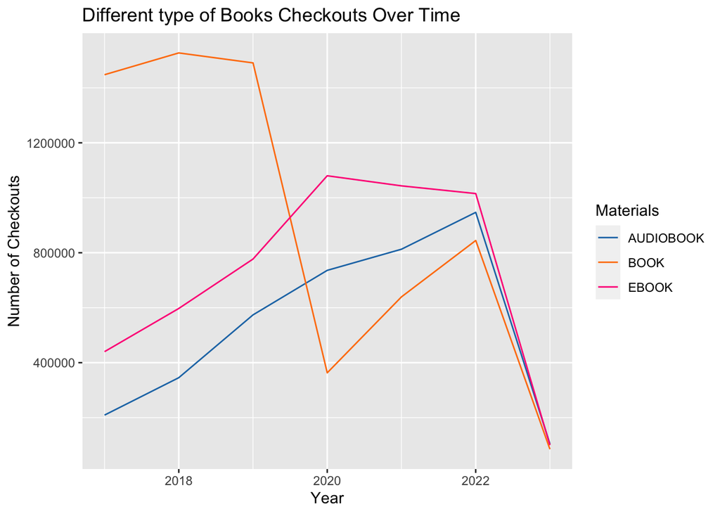

### Your Choice

The last chart is up to you. It could be a line plot, scatter plot, histogram, bar plot, stacked bar plot, and more. Here are some requirements to help guide your design:

- You must have clear x and y axis labels
- The chart needs a clear title
- You need a legend for your different line colors and a clear legend title

-Include a chart. Make sure to describe why you included the chart, and what patterns emerged

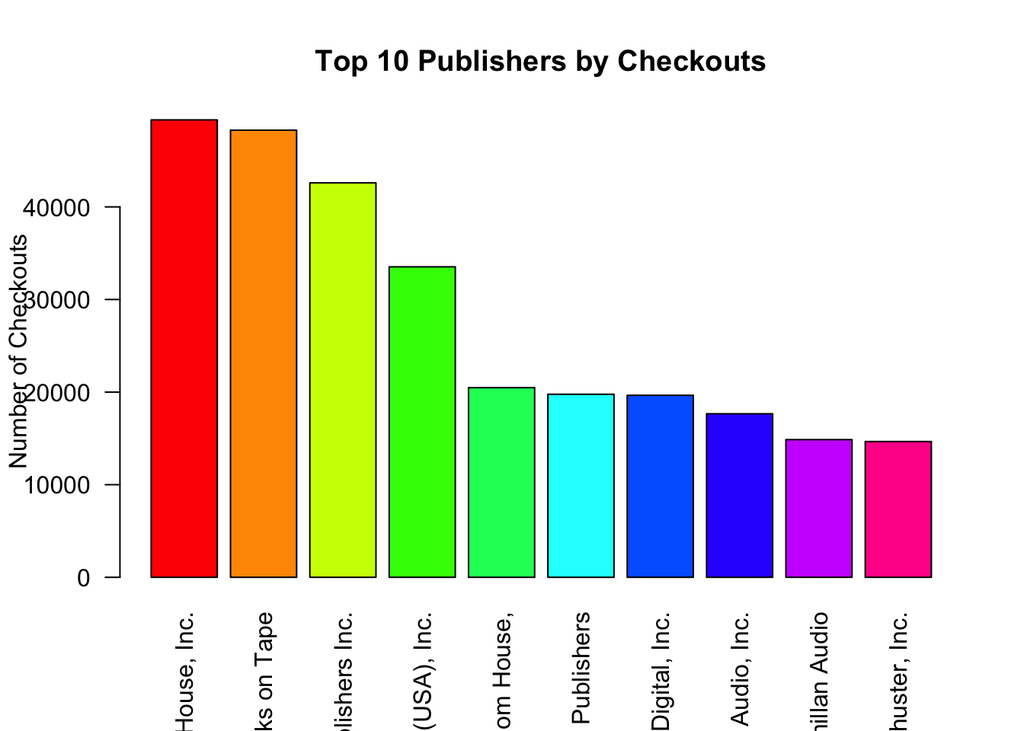